# Assignment 3

# Show all Predicted OutPut Through Pie Chat

**1: Predicted OutPut of "LogisticRegression" Algorithm:**

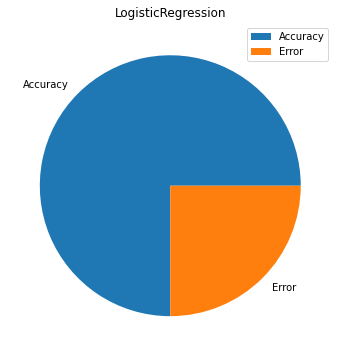

**2: Predicted OutPut of "BernoulliNB" Algorithm:**

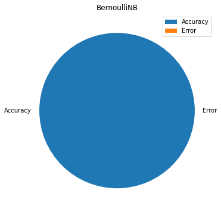

**3: Predicted OutPut of "RandomForestClassifier" Algorithm:**

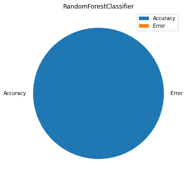

**4: Predicted OutPut of "LinearSVC" Algorithm:**

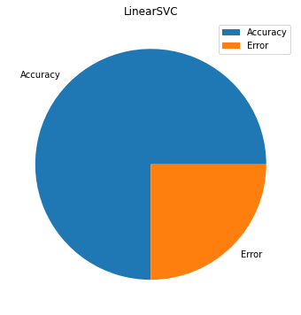

**5: Predicted OutPut of "KNeighborsClassifier" Algorithm:**

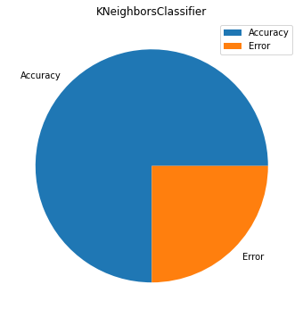

**6: Predicted OutPut of "ExtraTreeClassifier" Algorithm:**

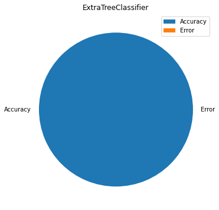

**7: Predicted OutPut of "DecisionTreeClassifier" Algorithm:**

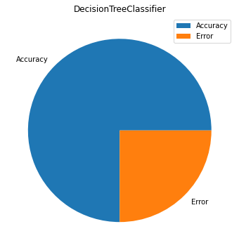

**8: Predicted OutPut of "MLPClassifier" Algorithm:**

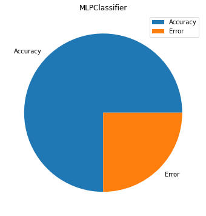

**9: Predicted OutPut of "GradientBoostingClassifier" Algorithm:**

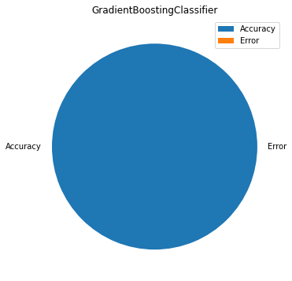

**10: Predicted OutPut of "BaggingClassifier" Algorithm:**

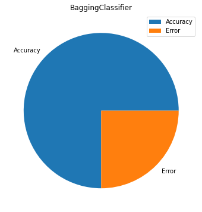

**11: Predicted OutPut of "ExtraTreesClassifier" Algorithm:**

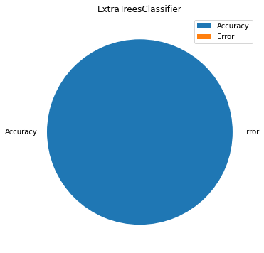

**12: Predicted OutPut of "SGDClassifier" Algorithm:**

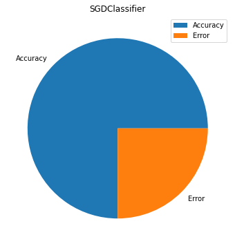

**13: Predicted OutPut of "RidgeClassifierCV" Algorithm:**

[16 more figures not shown]

```python
# Define a Function for showing tha Pie Chat of each Model
def printPredictPaiChat(title, predict):
    lable = ["Accuracy","Error"]
    values = [ (100 * accuracy_score(testData_output, predict)),(100 * mean_squared_error(testData_output, predict))]

    fig = plt.figure(figsize = (8, 6))
    plt.pie(values, labels = lable)
    plt.title(title)
    plt.legend()

    plt.show()


# Call Function through loop
count = 0
for x in prediction:
    count = count + 1
    print('\n')
    printmd('<b>{0}: Predicted OutPut of "{1}" Algorithm:</b>'.format(count ,x), color="blue")
    printPredictPaiChat(x ,prediction[x])
```

## Selection Of Best Model

```
Create a new DataFrame "performanceAllModels" that have all mobel name and their performanve record.
```

```python
performanceAllModels = pd.DataFrame(columns=["Model", "Accuracy", "Error"])
print(performanceAllModels)

count = 0
for x in prediction:
    new_row = {  "Model": x,
           "Accuracy": "{:.0%}".format(accuracy_score(testData_output, prediction[x])),
           "Error": "{:.0%}".format(mean_squared_error(testData_output, prediction[x]))
          }
    performanceAllModels = performanceAllModels.append(new_row, ignore_index=True)
```

```
Empty DataFrame
Columns: [Model, Accuracy, Error]
Index: []
```

#### Import prettytable Library for showing a beautyfull table and create an object "modelResult" and pass column name.

```python
#import import_ipynb
#from prettytable import PrettyTable
#from tabulate import tabulate

modelResult = PrettyTable()
modelResult.field_names = ["No.","Model", "Accuracy", "Error"]
```

#### Pass DataFrame "performanceAllModels" data to "modelResult" object and than show that table.

```python
count = 1
for index, rows in performanceAllModels.iterrows():
    # Create list for the current row
    my_list =[count, rows.Model, rows.Accuracy, rows.Error]

    # append the list to the PrettyTable
    count = count + 1
    modelResult.add_row(my_list)
```

```python
print(modelResult.get_string(title="All Models Predictions"))
```

```
+--------------------------------------------------------+
|                 All Models Predictions                 |
+-----+-------------------------------+----------+-------+
| No. |             Model             | Accuracy | Error |
+-----+-------------------------------+----------+-------+
|  1  |       LogisticRegression      |   75%    |  25%  |
|  2  |          BernoulliNB          |   100%   |   0%  |
|  3  |     RandomForestClassifier    |   100%   |   0%  |
|  4  |           LinearSVC           |   75%    |  25%  |
|  5  |      KNeighborsClassifier     |   75%    |  25%  |
|  6  |      ExtraTreeClassifier      |   100%   |   0%  |
|  7  |     DecisionTreeClassifier    |   75%    |  25%  |
|  8  |         MLPClassifier         |   75%    |  25%  |
|  9  |   GradientBoostingClassifier  |   100%   |   0%  |
|  10 |       BaggingClassifier       |   75%    |  25%  |
|  11 |      ExtraTreesClassifier     |   100%   |   0%  |
|  12 |         SGDClassifier         |   75%    |  25%  |
|  13 |       RidgeClassifierCV       |   100%   |   0%  |
|  14 |        RidgeClassifier        |   100%   |   0%  |
|  15 |  PassiveAggressiveClassifier  |   75%    |  25%  |
|  16 |   GaussianProcessClassifier   |   75%    |  25%  |
|  17 |       AdaBoostClassifier      |   75%    |  25%  |
|  18 |         MultinomialNB         |   75%    |  25%  |
|  19 |        NearestCentroid        |   75%    |  25%  |
|  20 |             NuSVC             |   75%    |  25%  |
|  21 |           Perceptron          |   50%    |  50%  |
|  22 |              SVC              |   75%    |  25%  |
|  23 |        GaussianMixture        |   50%    |  50%  |
|  24 |  LinearDiscriminantAnalysisB  |   100%   |   0%  |
|  25 |           GaussianNB          |   100%   |   0%  |
|  26 |        LabelPropagation       |   50%    |  50%  |
|  27 |         LabelSpreading        |   50%    |  50%  |
|  28 | QuadraticDiscriminantAnalysis |   75%    |  25%  |
+-----+-------------------------------+----------+-------+
```

#### Filter the best Models and store in a new dataFrame "bestPerformanceModela" Than Pass "bestPerformanceModela" data to "modelResult" object and display the table.

```python
# store best models data
bestPerformanceModela = performanceAllModels[performanceAllModels['Accuracy'].isin(["100%"])]

# clear table and stode best model data in it
modelResult.clear_rows()
count = 1
for index, rows in bestPerformanceModela.iterrows():
    # Create list for the current row
    my_list =[count, rows.Model, rows.Accuracy, rows.Error]

    # append the list to the PrettyTable
    count = count + 1
    modelResult.add_row(my_list)
```

```python
print(modelResult.get_string(title="Best Predictions Models"))
```

```
+------------------------------------------------------+
|               Best Predictions Models                |
+-----+-----------------------------+----------+-------+
| No. |            Model            | Accuracy | Error |
+-----+-----------------------------+----------+-------+
|  1  |         BernoulliNB         |   100%   |   0%  |
|  2  |    RandomForestClassifier   |   100%   |   0%  |
|  3  |     ExtraTreeClassifier     |   100%   |   0%  |
|  4  |  GradientBoostingClassifier |   100%   |   0%  |
|  5  |     ExtraTreesClassifier    |   100%   |   0%  |
|  6  |      RidgeClassifierCV      |   100%   |   0%  |
|  7  |       RidgeClassifier       |   100%   |   0%  |
|  8  | LinearDiscriminantAnalysisB |   100%   |   0%  |
|  9  |          GaussianNB         |   100%   |   0%  |
+-----+-----------------------------+----------+-------+
```

# Mearge Train and Test Data

```python
allData = trainData.append(testData,  ignore_index = True)
print(tabulate(allData, headers='keys', tablefmt='psql'))
```

```
+----+----------+----------+--------+---------+---------+----------+
|    |   height |   weight | hair   | beard   | scarf   | gender   |
|----+----------+----------+--------+---------+---------+----------|
|  0 |  180.3   |      196 | Bald   | Yes     | No      | Male     |
|  1 |  170     |      120 | Long   | No      | No      | Female   |
|  2 |  178.5   |      200 | Short  | No      | No      | Male     |
|  3 |  163.4   |      110 | Medium | No      | Yes     | Female   |
|  4 |  175.222 |      220 | Short  | Yes     | No      | Male     |
|  5 |  165     |      150 | Medium | No      | Yes     | Female   |
|  6 |  179.1   |      185 | Long   | Yes     | No      | Male     |
|  7 |  160.5   |      130 | Short  | No      | No      | Female   |
|  8 |  177.8   |      160 | Bald   | No      | No      | Male     |
|  9 |  161.1   |      100 | Medium | No      | No      | Female   |
+----+----------+----------+--------+---------+---------+----------+
```

# Lable Encoging on All Data

```python
allData['gender'] = leGender.fit_transform(allData['gender'])
allData['scarf'] = leScarf.fit_transform(allData['scarf'])
allData['beard'] = leBeard.fit_transform(allData['beard'])
allData['hair'] = leHair.fit_transform(allData['hair'])

print(allData)
```

```
   height  weight  hair  beard  scarf  gender
0  180.30     196     0      1      0       1
1  170.00     120     1      0      0       0
2  178.50     200     3      0      0       1
3  163.40     110     2      0      1       0
4  175.22     220     3      1      0       1
5  165.00     150     2      0      1       0
6  179.10     185     1      1      0       1
7  160.50     130     3      0      0       0
8  177.80     160     0      0      0       1
9  161.10     100     2      0      0       0
```

# Siplit Input and Outout

```python
allData_input = allData.iloc[:,:5]
print(allData_input)
```

```
   height  weight  hair  beard  scarf
0  180.30     196     0      1      0
1  170.00     120     1      0      0
2  178.50     200     3      0      0
3  163.40     110     2      0      1
4  175.22     220     3      1      0
5  165.00     150     2      0      1
6  179.10     185     1      1      0
7  160.50     130     3      0      0
8  177.80     160     0      0      0
9  161.10     100     2      0      0
```

```python
allData_output = allData.iloc[:,5]
print(allData_output)
```

```
0    1
1    0
2    1
3    0
4    1
5    0
6    1
7    0
8    1
9    0
Name: gender, dtype: int32
```

# Train Best Model on all data

```python
rfc.fit(allData_input ,allData_output)
```

```
RandomForestClassifier()
```

### Create some Function for validate input

```python
# check input is float or not
def check_user_input(val):
    while(1):
        try:
             # Convert it into float
            val = int(val)
            return val
        except ValueError:
             val = input("No.. Please Enter Valid Input:")

# check input is in given value or not
def check_user_hair(val):
    while(val.lower() != "bald" and val.lower() != "long" and val.lower() != "short" and val.lower() != "medium"):
        val = input("No.. Please Enter Valid Input:")

    if(val.lower() == "bald"):
        return "Bald"
    elif(val.lower() == "long"):
        return "Long"
    elif(val.lower() == "short"):
        return "Short"
    else:
        return "Medium"


# check input is in yes or no
def check_user_BS(val):
    while(val.lower() != "no" and val.lower() != "yes"):
        val = input("No.. Please Enter Valid Input:")

    if(val.lower() == "no"):
        return "No"
    else:
        return "Yes"
```

### Create Function for getting Unseen Data

- This Function will get user input and doing some preprocessing like exterect feature and lable encoding etc
- Than pass this input or unseen data to model and pridict some output
- Lable Decode that pridicted output and shows the pridiction result in human readable form

```python
#function For get user input
def unseenData():
    #input from user
    height = input("Please Enter Your Height ( in centimeter):")
    height = check_user_input(height)

    weight = input("Please Enter Your weight ( in pounds):")
    weight = check_user_input(weight)

    hair = input("Please Enter Your Hair Length ( Bald/Long/Short/Medium):")
    hair = check_user_hair(hair)

    beard = input("Do You Have Beard? ( Yes/No):")
    beard = check_user_BS(beard)

    scarf = input("Do You wear Scarf? ( Yes/No):")
    scarf = check_user_BS(scarf)


    #store user input in DataFrame
    userInput = pd.DataFrame({'height': height,
                              'weight': weight,
                              'hair': [hair,'Medium','Short','Bald'],
                              'beard': [beard,'Yes','No','No'],
                              'scarf': [scarf,'Yes','No','No']
                             })

    #Display input DataFrame
    print("\n\nUser Input or Unsean Data:\n")
    print(tabulate(userInput.loc[:0,:], headers='keys', tablefmt='psql'))


    #lable indoding  on input data
    userInput['scarf'] = leScarf.fit_transform(userInput['scarf'])
    userInput['beard'] = leBeard.fit_transform(userInput['beard'])
    userInput['hair'] = leHair.fit_transform(userInput['hair'])

    #show incoded data
    print("\nUser Input After Lable Encoding:\n")
    print(tabulate(userInput.loc[:0,:], headers='keys', tablefmt='psql'))

    #Pass input to Model for prediction
    userOutput = rfc.predict(userInput)
    #lable decoding
    userOutput = leGender.inverse_transform(userOutput)
    #display model prediction
    print() #display colored output
    printmd('Pridicted Output by Model: <b>"{0}"</b>'.format(userOutput[0]), color="blue")
    print()
```

### Get Unseen Data:

```python
unseenData()
```

```
Please Enter Your Height ( in centimeter):180
Please Enter Your weight ( in pounds):125
Please Enter Your Hair Length ( Bald/Long/Short/Medium):long
Do You Have Beard? ( Yes/No):no
Do You wear Scarf? ( Yes/No):yes


User Input or Unsean Data:

+----+----------+----------+--------+---------+---------+
|    |   height |   weight | hair   | beard   | scarf   |
|----+----------+----------+--------+---------+---------|
|  0 |      180 |      125 | Long   | No      | Yes     |
+----+----------+----------+--------+---------+---------+

User Input After Lable Encoding:

+----+----------+----------+--------+---------+---------+
|    |   height |   weight |   hair |   beard |   scarf |
|----+----------+----------+--------+---------+---------|
|  0 |      180 |      125 |      1 |       0 |       1 |
+----+----------+----------+--------+---------+---------+
```

Pridicted Output by Model: **"Female"**

```python
unseenData()
```

```
Please Enter Your Height ( in centimeter):210
Please Enter Your weight ( in pounds):230
Please Enter Your Hair Length ( Bald/Long/Short/Medium):medium
Do You Have Beard? ( Yes/No):yes
Do You wear Scarf? ( Yes/No):no


User Input or Unsean Data:

+----+----------+----------+--------+---------+---------+
|    |   height |   weight | hair   | beard   | scarf   |
|----+----------+----------+--------+---------+---------|
|  0 |      210 |      230 | Medium | Yes     | No      |
+----+----------+----------+--------+---------+---------+

User Input After Lable Encoding:

+----+----------+----------+--------+---------+---------+
|    |   height |   weight |   hair |   beard |   scarf |
|----+----------+----------+--------+---------+---------|
|  0 |      210 |      230 |      1 |       1 |       0 |
+----+----------+----------+--------+---------+---------+
```

Pridicted Output by Model: **"Male"**